# 2 Toxicodynamic NAM Compilation

Katie Paul Friedman

2024-06-04

```r
apcra.pro <- fread('./source/chem/apcra_pro.csv') # APCRA prospective chemicals
apcra.pro[,c(1) := NULL]
setnames(apcra.pro, c('V2','V3','V4'), c('DTXSID','CASRN','preferred_name'))
apcra.pro <- apcra.pro[-c(1),]
apcra.pro[,list := 'Pro']

# annotate chemicals that are also in APCRA retrospective case study - these will likely be data-rich
apcra.ret <- as.data.table(read.xlsx('./source/chem/Supp_File_2_pod_ratio_master_final.xlsx', sheet=1))
apcra.pro[,apcra.ret := 0]
apcra.ret.dtxsids <- apcra.ret[,DTXSID]
apcra.pro[DTXSID %in% apcra.ret.dtxsids, apcra.ret := 1]
```

```r
#load('./source/in_vitro/tier1_NAMs_apcra_pro_04032023.RData')
load('./source/in_vitro/tier1_NAMs_apcra_pro_02262024.RData')
load(file='./source/chem/apcra_chem_ad.RData')
```

# 1 Step 1: ToxCast Dataset

## 1.1 Understand importance of assay technology for in vitro POD

- Take a look at whole invitrodb version 3.5 for as many chemicals as possible.

### 1.1.1 Load invitrodb data to get potency estimates

```r
chems <- tcplLoadChem()
mc5 <- tcplPrepOtpt(tcplLoadData(val=chems$spid, lvl=5, type = 'mc',fld='spid'))
mc6 <- tcplPrepOtpt(tcplLoadData(lvl=6, fld='m4id', val=mc5$m4id, type='mc'))
setDT(mc6)
mc6_mthds <- mc6[ , .( mc6_mthd_id = paste(mc6_mthd_id, collapse=",")), by = m4id]
mc6_flags <- mc6[ , .( flag = paste(flag, collapse=";")), by = m4id]
mc5$mc6_flags <- mc6_mthds$mc6_mthd_id[match(mc5$m4id, mc6_mthds$m4id)]
mc5[, flag.length := ifelse(!is.na(mc6_flags), count.fields(textConnection(mc6_flags), sep =','), NA)]

# filter the dataset, with coarse filters
filter_mc5 <- function(dat){
dat[hitc==1 & flag.length < 3, use.me := 1]
dat[hitc==1 & is.na(flag.length), use.me := 1]
dat[hitc==1 & flag.length >= 3, use.me := 0]
dat[fitc %in% c(36,45), use.me := 0]
dat[hitc==-1, use.me := 0] # make hitc interpretable as a positive sum
dat[use.me==0, modl_ga := as.numeric(NA)]
dat[use.me==0, hitc := 0]
dat[hitc==0, modl_ga := as.numeric(NA)]
dat[hitc==0, modl_acc := as.numeric(NA)]
  return(dat)
}

filter_mc5(mc5)

mc5[hitc==1,ac50_uM := ifelse(!is.na(modl_ga), 10^modl_ga, NA)]
mc5[hitc==1, acc_uM := ifelse(!is.na(modl_acc), 10^modl_acc, NA)]

# understand assay source as a surrogate for technology/bioactivity
mc5[,asnm := tstrsplit(aenm, "_", fixed=TRUE, keep=c(1))]
mc5.hitc1 <- mc5[hitc==1]
mc5.hitc1[grep('_dn',aenm), direction := 'dn']
mc5.hitc1[asnm=='ATG' & direction=='dn', use.me := 0]
mc5.hitc1[use.me==0, hitc := 0]

mc5.hitc1 <- mc5.hitc1[hitc==1] # this takes out ~1500 rows or so by removing the ATG _dn

mc5.hitc1[,modl_ga_5p := quantile(modl_ga, probs=c(0.05),na.rm=TRUE), by=list(dsstox_substance_id)]
mc5.hitc1[,asnm_modl_ga_5p := quantile(modl_ga, probs=c(0.05),na.rm=TRUE), by=list(dsstox_substance_id, asnm)]

mc5.hitc1[,modl_acc_5p := quantile(modl_acc, probs=c(0.05),na.rm=TRUE), by=list(dsstox_substance_id)]
mc5.hitc1[,asnm_modl_acc_5p := quantile(modl_acc, probs=c(0.05),na.rm=TRUE), by=list(dsstox_substance_id, asnm)]
```

- The modl_acc is very similar to the modl_ga.

```r
acc2ac50 <- lm(modl_ga ~ modl_acc,
            data= mega.mc5.hitc1)

summary(acc2ac50)
```

```
##
## Call:
## lm(formula = modl_ga ~ modl_acc, data = mega.mc5.hitc1)
##
## Residuals:
##     Min      1Q  Median      3Q     Max
## -7.6747 -0.1000  0.0106  0.1247  2.7944
##
## Coefficients:
##             Estimate Std. Error t value Pr(>|t|)
## (Intercept) 0.283725   0.003772   75.22   <2e-16 ***
## modl_acc    0.816274   0.002781  293.50   <2e-16 ***
## ---
## Signif. codes:  0 '***' 0.001 '**' 0.01 '*' 0.05 '.' 0.1 ' ' 1
##
## Residual standard error: 0.3101 on 20634 degrees of freedom
##   (5 observations deleted due to missingness)
## Multiple R-squared:  0.8068, Adjusted R-squared:  0.8067
## F-statistic: 8.614e+04 on 1 and 20634 DF,  p-value: < 2.2e-16
```

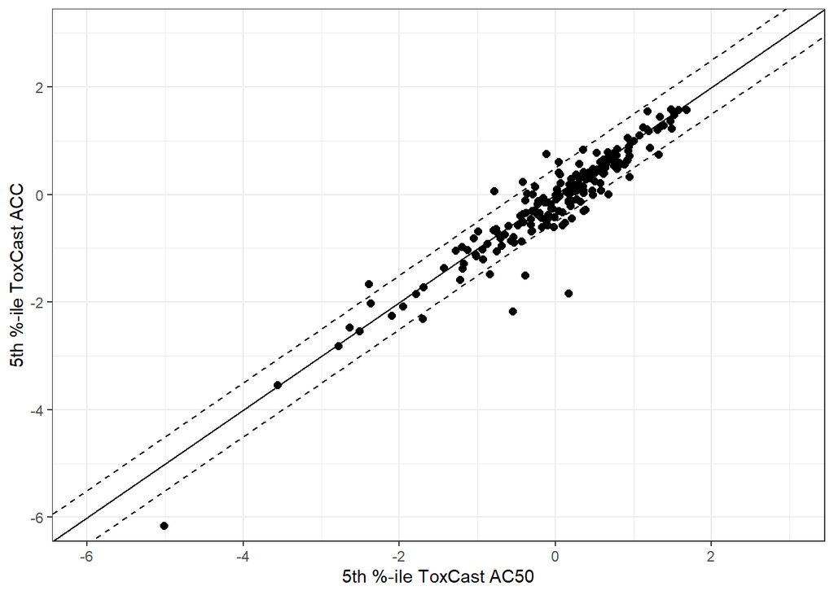

```r
ggplot(data=mega.mc5.hitc1, aes(x=modl_ga_5p, y=modl_acc_5p))+
geom_point(size=2)+
  #geom_text(angle=90, vjust=-1, hjust=0.5)+
  #geom_text_repel(max.overlaps = 100)+
  xlab('5th %-ile ToxCast AC50') +
  ylab('5th %-ile ToxCast ACC') +
  geom_abline(slope=1, intercept=0) +
  geom_abline(slope=1, intercept=1/2, linetype="dashed") +
  geom_abline(slope=1, intercept=-1/2, linetype="dashed") +
  theme_bw()+
  coord_cartesian(xlim=c(-6,3), ylim=c(-6,3))
```

# 2 Step 2: Build APCRA Case Study Data Set for POD-NAM

## 2.1 STM data

- MC data for only 61 chemicals in case study list.

```r
mc5.stm <- mc5[grep('STM_H9',aenm)]
mc5.stm <- mc5.stm[dsstox_substance_id %in% apcra.list[,DTXSID]]
length(unique(mc5.stm$dsstox_substance_id)) # only 61 chemicals
```

- Stemina data: first check for full dataset.
- We have 199/201 between the sc and mc screens; missing only DTXSID4032376 and DTXSID108952020. Consider this complete.

```r
stm.aeid <- tcplLoadAeid(val=14,fld='asid',add.fld='acid')

sc2.stm <- tcplPrepOtpt(tcplLoadData(lvl=2,type='sc',fld='aeid',val=stm.aeid[,aeid]))
sc2.stm <- sc2.stm[dsstox_substance_id %in% apcra.list[,DTXSID]]
length(unique(sc2.stm$dsstox_substance_id)) #179

#apcra.list[!DTXSID %in% sc2.stm[,dsstox_substance_id]] # 22 substances

stm.dtxsid <- union(unique(mc5.stm[,dsstox_substance_id]), unique(sc2.stm[,dsstox_substance_id]))

#apcra.list[!DTXSID %in% stm.dtxsid] # missing only DTXSID4032376 and DTXSID108952020; so only 199/201 screened. Consider complete.

apcra.list[, stm.sc := 0]
apcra.list[DTXSID %in% sc2.stm[,dsstox_substance_id], stm.sc := 1]
apcra.list[, stm.mc := 0]
apcra.list[DTXSID %in% mc5.stm[,dsstox_substance_id], stm.mc := 1]
```

- Now filter to determine positive/negative desigation for Stemina.
- Calculate a draft dev tox flag that includes specificity as an additional filter. Most recent paper from Zurlinden et al. 2019 suggests that cytotoxicity in this model is not necessarily independent of developmental toxicity.

```r
neg.stm.dtxsid <- apcra.list[stm.sc==1 & stm.mc==0, DTXSID]
examples <- sc2.stm[aeid==1691 & dsstox_substance_id %in% neg.stm.dtxsid & hitc==1]
#sc0.stm <- tcplPrepOtpt(tcplLoadData(lvl=0,type='sc',fld='acid',val=1031))

mc5.stm <- mc5.stm[aeid %in% c(1691,1858)]
```

```r
# 5 substances were positive in sc and not tested in mc for some reason
add <- sc2.stm[dsstox_substance_id %in% examples[,dsstox_substance_id] & aeid==1691]
add <- add[,c('spid','chid','casn','chnm', 'dsstox_substance_id','code','aeid', 'bmad','max_med','hitc','coff','resp_unit','conc_unit')]
add[, modl_ga := 2] # make the top tested concentration the potency for these 5
add[, use.me := 1]
mc5.stm.test <- rbind(mc5.stm, add, use.names=TRUE, fill=TRUE)

apcra.list[,stm.any := 0]
apcra.list[stm.mc==1|stm.sc==1,stm.any := 1]
#nrow(apcra.list[stm.any==1])#199
```

## 2.2 MEA data

- MEA acute data were released in invitrodb v3.5, but not sc data.

```r
# check to see what we have
mc5.mea <-mega.mc5[grep('CCTE_Shafer_MEA_acute',aenm)]
mc5.mea <- mc5.mea[dsstox_substance_id %in% apcra.list[,DTXSID]]
#length(unique(mc5.mea$dsstox_substance_id)) #133

apcra.list[!DTXSID %in% mc5.mea[,dsstox_substance_id], mea.acute :=0]
apcra.list[DTXSID %in% mc5.mea[,dsstox_substance_id], mea.acute :=1]
```

```r
# tried to find the ~65 missing substances, but could not find them in other data sources
mea.missing <- apcra.list[mea.acute==0, DTXSID]
sc0.mea <- tcplPrepOtpt(tcplLoadData(lvl=0,type='sc',fld='acid', val=1916))
sc0.mea <- sc0.mea[dsstox_substance_id %in% mea.missing]

apcra.list[DTXSID %in% sc0.mea[,dsstox_substance_id],mea.acute.sc :=1]
#nrow(apcra.list[mea.acute.sc==1|mea.acute==1]) #133
#nrow(apcra.list[mea.acute==0 & mea.acute.sc==1]) #0
#apcra.list[mea.acute.sc==1 | mea.acute==1, mea.acute.any := 1]
#apcra.list[is.na(mea.acute.any), mea.acute.any := 0]
```

## 2.3 Total mc5 in ToxCast

```r
mc5.apcra <- mc5[dsstox_substance_id %in% apcra.list[,DTXSID]] # only APCRA chems
mc5.apcra <- mc5.apcra[asnm != 'CCTE']

stm.aeids <- unique(mc5.stm.test$aeid)
mea.aeids <- unique(mc5.mea$aeid)
mc5.apcra <- mc5.apcra[-(aeid %in% c(stm.aeids, mea.aeids))]
mc5.stm.test[is.na(aenm) & aeid==1691, aenm := "STM_H9_OrnCyssISnorm_ratio_dn"]

setdiff(colnames(mc5.apcra), colnames(mc5.mea))
#colnames(mc5.mea)

mega.mc5 <- rbind(mc5.apcra, mc5.mea, mc5.stm.test)

mega.mc5 <- mega.mc5[dsstox_substance_id %in% apcra.list[,DTXSID]]

mega.mc5.hitc1 <- mega.mc5[hitc==1]
mega.mc5.hitc1[grep('_dn',aenm), direction := 'dn']

mega.mc5.hitc1[asnm=='ATG' & direction=='dn', use.me := 0]
mega.mc5.hitc1[use.me==0, hitc := 0]
mega.mc5.hitc1 <- mega.mc5.hitc1[hitc==1] # this takes out ~1500 rows or so by removing the ATG _dn

mega.mc5.hitc1[,modl_ga_5p := quantile(modl_ga, probs=c(0.05),na.rm=TRUE), by=list(dsstox_substance_id)]
mega.mc5.hitc1[,asnm_modl_ga_5p := quantile(modl_ga, probs=c(0.05),na.rm=TRUE), by=list(dsstox_substance_id, asnm)]
#unique(mega.mc5.hitc1$asnm) everything, 17 asid
mega.mc5.hitc1[,ac50_5p := quantile(ac50_uM, probs=c(0.05),na.rm=TRUE), by=list(dsstox_substance_id)]
mega.mc5.hitc1[,asnm_ac50_5p := quantile(ac50_uM, probs=c(0.05),na.rm=TRUE), by=list(dsstox_substance_id, asnm)]

mega.mc5.hitc1[,modl_acc_5p := quantile(modl_acc, probs=c(0.05),na.rm=TRUE), by=list(dsstox_substance_id)]
mega.mc5.hitc1[,asnm_modl_acc_5p := quantile(modl_acc, probs=c(0.05),na.rm=TRUE), by=list(dsstox_substance_id, asnm)]
#unique(mega.mc5.hitc1$asnm) everything, 17 asid
mega.mc5.hitc1[,acc_5p := quantile(acc_uM, probs=c(0.05),na.rm=TRUE), by=list(dsstox_substance_id)]
mega.mc5.hitc1[,asnm_acc_5p := quantile(acc_uM, probs=c(0.05),na.rm=TRUE), by=list(dsstox_substance_id, asnm)]
```

## 2.4 Make wide version

- Minimum ACC potency by vendor/source included in case study.

```r
# CCTE is only Shafer acute data

asnm.tnams <- dcast.data.table(mega.mc5.hitc1,
                              chnm + dsstox_substance_id + modl_acc_5p ~ asnm,
                              value.var = c('modl_acc'),
                              fun.aggregate = min)

for (j in 1:ncol(asnm.tnams)) set(asnm.tnams, which(is.infinite(asnm.tnams[[j]])), j, NA)

asnm.tnams <- asnm.tnams[,c('chnm','dsstox_substance_id','modl_acc_5p','ATG','BSK','NVS','CCTE','STM')]
```

## 2.5 Retrieve ER and AR model data

```r
cerapp <- as.data.table(dbGetQuery(con, "select model_generic_chemical_cerapp_score.*
                                       from prod_internal_invitrodb_v3_5.model_generic_chemical_cerapp_score;"))

compara <- as.data.table(dbGetQuery(con, "select model_generic_chemical_compara_scores.*
                                         from prod_internal_invitrodb_v3_5.model_generic_chemical_compara_scores;"))

er <- as.data.table(dbGetQuery(con, "select * from prod_internal_invitrodb_v3_5.model_generic_chemical_er_scores;"))
ar <- as.data.table(dbGetQuery(con, "select * from prod_internal_invitrodb_v3_5.model_generic_chemical_ar_scores;"))
hth295r <- as.data.table(dbGetQuery(con, "select * from prod_internal_invitrodb_v3_5.model_generic_chemical_hth295r_scores;"))
```

- Save RData file.

```r
save(apcra.list,
     asnm.tnams,
     cerapp,
     compara,
     er,
     ar,
     hth295r,
     mega.mc5,
     mega.mc5.hitc1,
     sc2.stm,
     file='./source/invitrodb_apcra_pro_invitrodb3_5_2023.RData')
```

```r
load('./source/in_vitro/tier1_NAMs_apcra_pro_04032023.RData')
```

# 3 Step 3: Add Broad Profiling NAMs

- Add HTTr and HTPP summary bioactivity values to ToxCast data for case study.

## 3.1 Merge with HTTr and HTPP

```r
# load in HTTr data

#httr.pod <- as.data.table(read.xlsx('./source/podAcrossDomains 2021-04-01.xlsx', sheet=1,colNames = TRUE))
#httr.pod.apcra <- httr.pod[dtxsid %in% apcra.pro$dsstox_substance_id]
#write.xlsx(httr.pod.apcra, "./source/HTTr_podAcrossDomains 2021-04-01.xlsx")

#RSJ advises to use pod_sig

httr.u2os <- as.data.table(read.xlsx('./source/super_target_boxplot_U2OS_u2os_toxcast_pfas_pe1_normal_v2_screen_large_gsea_0.9_1_3_summary.xlsx', sheet=1, colNames=TRUE))



httr.mcf7 <- as.data.table(read.xlsx('./source/super_target_boxplot_MCF7_mcf7_ph1_pe1_normal_block_123_allPG_screen_large_gsea_0.9_1_3_summary.xlsx', sheet=1, colNames=TRUE))

httr.heparg <- as.data.table(read.xlsx('./source/super_target_boxplot_HepaRG_heparg2d_toxcast_pfas_pe1_normal_screen_large_gsea_0.9_1_3_summary.xlsx', sheet=1, colNames=TRUE))

colnames(httr.u2os)

setnames(httr.u2os, c('pod_sig'), c('httr.u20s.pod.sig'))
setnames(httr.mcf7, c('pod_sig'), c('httr.mcf7.pod.sig'))
setnames(httr.heparg, c('pod_sig'), c('httr.heparg.pod.sig'))

httr.u2os <- httr.u2os[, .SD[which.min(httr.u20s.pod.sig)], by='dtxsid']
httr.mcf7 <- httr.mcf7[, .SD[which.min(httr.mcf7.pod.sig)], by='dtxsid']
httr.heparg <- httr.heparg[, .SD[which.min(httr.heparg.pod.sig)], by='dtxsid']

httr.pod <- merge.data.table(httr.u2os[,c('name','dtxsid','httr.u20s.pod.sig')],
                             httr.mcf7[,c('dtxsid','httr.mcf7.pod.sig')],
                             by=c('dtxsid'),
                             all.x=TRUE,
                             all.y=TRUE)

httr.pod <- merge.data.table(httr.pod,
                             httr.heparg[,c('dtxsid','httr.heparg.pod.sig')],
                             by=c('dtxsid'),
                             all.x=TRUE,
                             all.y=TRUE)


httr.pod <- httr.pod[dtxsid %in% apcra.list[,DTXSID]]
diff <- setdiff(apcra.list$DTXSID, httr.pod$dtxsid)
apcra.list[DTXSID %in% diff]
apcra.list[,httr.any := 1]
apcra.list[DTXSID %in% diff, httr.any := 0]
```

```r
#dput(colnames(httr.pod))
asnm.tier1 <- merge.data.table(asnm.tnams,
                               httr.pod[,c('dtxsid','httr.u20s.pod.sig', 'httr.mcf7.pod.sig', 'httr.heparg.pod.sig')],
                               by.x=c('dsstox_substance_id'),
                               by.y=c('dtxsid'))
```

- Load HTPP data
- HTPP is from Johanna Nyffeler, Sept 2020

```r
# get HTPP data
# using the minimum PAC from global and category level analysis of the new U2OS screen.
# filter imposed: hit==1 if continuous hitcall >0.5

load(file='./source/U2OS_ToxCast htpp_pac APCRA_pro chemicals.RData')
PACList <- as.data.table(PACList)

# unique(PACList$approach)
# pac = potency in log10-uM
# hit = binary hitcall
# hitcall = hitcall probability
# top_over_cutoff = estimate of effect size

PACList.apcra = PACList %>%
  filter(dtxsid %in% apcra.list$DTXSID)

#length(unique(PACList.apcra$dtxsid)) # 194 screened

PACList.apcra[,htpp.min := ifelse(!is.na(pac), min(pac, na.rm=TRUE), 1000), by=list(dtxsid)]

htpp.hitc1 <- unique(PACList.apcra[hit==1, c('dtxsid','casrn','chem_name','htpp.min','hit','hitcall')]) #152 out of 194

apcra.list[DTXSID %in% PACList.apcra$dtxsid, htpp.u2os :=1]

asnm.tier1$htpp.u2os.pac.min <- htpp.hitc1$htpp.min[match(asnm.tier1$dsstox_substance_id,
                                                            htpp.hitc1$dtxsid)]
```

- Load in ASTAR

```r
#load('./source/APCRA2_Astar_summary_210214.Rdata')
load('./source/APCRA2_Astar_final_210530.Rdata')
#APCRA_Astar <- as.data.table(APCRA_Astar)
APCRA_Astar <- as.data.table(Astar_HIPPTox)

astar.samples <- tcplLoadChem(field='spid',val=unique(APCRA_Astar$EPA_SAMPLE_ID)) # have to be connected to invitrodb

APCRA_Astar$dsstox_substance_id <- astar.samples$dsstox_substance_id[match(APCRA_Astar$EPA_SAMPLE_ID,
                                                                           astar.samples$spid)]

asnm.tier1$Astar_BEAS2B_final <- APCRA_Astar$Astar_BEAS2B_final[match(asnm.tier1$dsstox_substance_id,
                                                                     APCRA_Astar$dsstox_substance_id)]

asnm.tier1$Astar_HepG2_final <- APCRA_Astar$Astar_HepG2_final[match(asnm.tier1$dsstox_substance_id,
                                                                     APCRA_Astar$dsstox_substance_id)]
asnm.tier1$Astar_HK2_final <- APCRA_Astar$Astar_HK2_final[match(asnm.tier1$dsstox_substance_id,
                                                                     APCRA_Astar$dsstox_substance_id)]

# edit 2-26-24, per Lit-Hsin Loo, values of 2.6 and greater indicate a negative response in the assay
#nrow(asnm.tier1[Astar_BEAS2B_final>2.6]) #100 times
asnm.tier1[Astar_BEAS2B_final> 2.6, Astar_BEAS2B_final := NA]
asnm.tier1[Astar_HepG2_final> 2.6, Astar_HepG2_final := NA]
asnm.tier1[Astar_HK2_final> 2.6, Astar_HK2_final := NA]
```

```r
asnm.tier1[,c('httr.u20s.pod.sig', 'httr.mcf7.pod.sig', 'httr.heparg.pod.sig')] <- log10(asnm.tier1[,c('httr.u20s.pod.sig', 'httr.mcf7.pod.sig', 'httr.heparg.pod.sig')])

asnm.tier1[,min.acc.targeted.nam := min(ATG,BSK,NVS,CCTE,STM, na.rm = TRUE), by=list(dsstox_substance_id)]
```

## 3.2 Compare to modl_acc 5th percentile

```r
asnm.tier1[, col_min := colnames(.SD)[apply(.SD,1,which.min)], .SDcols=c('ATG','BSK','NVS','CCTE','STM',
                                                                         'httr.u20s.pod.sig', 'httr.mcf7.pod.sig', 'httr.heparg.pod.sig',
                                                                         'htpp.u2os.pac.min',
                                                                         "Astar_HK2_final", "Astar_HepG2_final","Astar_BEAS2B_final")]

asnm.tier1[, min.httr.htpp.targetnams := min(ATG,BSK,NVS,CCTE,STM, httr.u20s.pod.sig, httr.mcf7.pod.sig, httr.heparg.pod.sig,htpp.u2os.pac.min,Astar_HK2_final, Astar_HepG2_final,Astar_BEAS2B_final, na.rm=TRUE), by=list(dsstox_substance_id)]
```

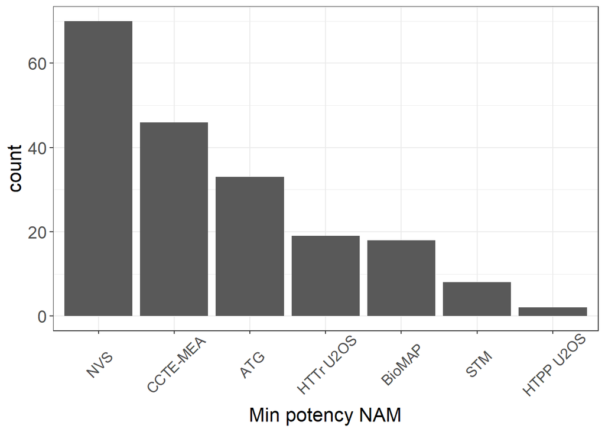

```r
fig2b <- ggplot(data=asnm.tier1[,.(count=.N), by=col_min], aes(x=reorder(col_min,(-count)),y=count))+
  geom_bar(stat='identity')+
  theme_bw() +
  theme(axis.text.x = element_text(angle=45, vjust=0.6, size=12),
        axis.text.y = element_text(size=14),
        axis.title = element_text(size=16))+
  xlab('Min potency NAM')+
  #ggtitle('Frequency of Minimum Value by DTXSID')+
  scale_x_discrete(breaks=c('NVS', 'BSK','ATG','CCTE','httr.u20s.pod.sig', 'STM',
                               'htpp.u2os.pac.min', 'httr.mcf7.pod.sig'),
                   labels = c('NVS', 'BioMAP','ATG','CCTE-MEA','HTTr U2OS', 'STM',
                               'HTPP U2OS', 'HTTr MCF7'))

fig2b
```

```r
file.dir <- paste('output/', sep='')
file.name <- paste('/Fig2b_invitro_mostpotent_', Sys.Date(), '.tiff', sep='')
file.path <- paste(file.dir, file.name, sep='')
dir.create(path=file.dir, showWarnings = FALSE, recursive = TRUE)
tiff(file.path, width=6, height=4, units='in', res=600)
fig2b
dev.off()
```

## 3.3 Heatmap of data and coverage

- Need to make missing data a different value from negative data
- Need to annotate analytical quality control pass/fail (AQC)
- Need to annotate APCRA Pro Only (or not)

```r
# asnm.tier1 is all in arithmetic units and this is not conducive to heatmapping
asnm.tier1.loguM <- as.data.frame(asnm.tier1)
cols <- c("ATG",
                         "BSK",
                          "CCTE",
                         "NVS",
                         "STM",
                         "httr.u20s.pod.sig",
                         "httr.mcf7.pod.sig",
                         "httr.heparg.pod.sig",
                         "htpp.u2os.pac.min",
                         "Astar_BEAS2B_final",
                         "Astar_HepG2_final",
                         "Astar_HK2_final")

# put numeric column values into log10 uM

asnm.tier1.loguM[cols] <- lapply(asnm.tier1.loguM[cols], log10)

asnm.tier1.loguM <- as.data.table(asnm.tier1.loguM)
setnames(asnm.tier1.loguM, c('CCTE', 'BSK'), c('CCTE-MEA', 'BioMAP'))

# make matrix for heatmap
mat <- asnm.tier1.loguM[,c("dsstox_substance_id",
                         #"CASRN",
                         "chnm",
                         "ATG",
                         "BioMAP",
                         "CCTE-MEA",
                         "NVS",
                         "STM",
                         "httr.u20s.pod.sig",
                         "httr.mcf7.pod.sig",
                         "httr.heparg.pod.sig",
                         "htpp.u2os.pac.min",
                         "Astar_BEAS2B_final",
                         "Astar_HepG2_final",
                         "Astar_HK2_final"
                         )]
```

- the targeted NAM matrix is not complete.
- CCTE-MEA = 133/201
- NVS = 166/201 - but 200/201 covered in sc
- BSK = 200/201
- ATG = 187/201

```r
length(unique(mega.mc5[asnm=='NVS']$dsstox_substance_id)) #166
```

```
## [1] 166
```

```r
length(unique(mega.mc5[asnm=='TOX21']$dsstox_substance_id)) #198
```

```
## [1] 198
```

```r
length(unique(mega.mc5[asnm=='BSK']$dsstox_substance_id)) #200
```

```
## [1] 200
```

```r
length(unique(mega.mc5[asnm=='ATG']$dsstox_substance_id)) #187
```

```
## [1] 187
```

```r
length(unique(mega.mc5[asnm=='CCTE']$dsstox_substance_id)) #133 # no single conc data released
```

```
## [1] 133
```

- Need to annotate for this incompleteness

```r
mat$aqc <- ad.tbl$aqc_indicator[match(mat$dsstox_substance_id,ad.tbl$DTXSID)]
mea.tested.dtxsid <- unique(mega.mc5[asnm=='CCTE']$dsstox_substance_id)
mat2 <- mat[!dsstox_substance_id %in% mea.tested.dtxsid, `CCTE-MEA` := 5]
atg.tested.dtxsid <- unique(mega.mc5[asnm=='ATG']$dsstox_substance_id)
mat2 <- mat2[!dsstox_substance_id %in% atg.tested.dtxsid, `ATG` := 5]

mat2 <- mat2 %>% mutate_all(function(x) ifelse(is.nan(x), NA, x))
mat2 <- mat2[order(aqc, `CCTE-MEA`, ATG)]
mat3 <- mat2[,lapply(.SD, function(x){ifelse(is.na(x),6,x)}), .SDcol=c(3:14)]
mat3 <- mat3 %>% mutate_all(function(x) ifelse(x==5, NA, x))
mat3 <- mat3 %>% mutate_all(function(x) ifelse(is.infinite(x), NA, x))

matrix <- as.matrix(mat3)
rownames(matrix) <- mat2[,dsstox_substance_id]
```

```r
# Make Complex Heatmap

## define the annotations df

anno_df <- data.frame(rownames(matrix))

# add whether it is APCRA Pro Only and if it is in applicability domain for screening and chemical name
anno_df$Pro <- ad.tbl$apcra.pro.only[match(anno_df[,1],
                                            ad.tbl$DTXSID)] # 1 means APCRA pro only
anno_df$chnm <- ad.tbl$preferred_name[match(anno_df[,1],
                                            ad.tbl$DTXSID)] # match in preferred name
anno_df$aqc <- ad.tbl$aqc_indicator[match(anno_df[,1],
                                          ad.tbl$DTXSID)] # 1 means pass AQC

colors_ha <- list(Pro = c('0'='white','1'='blue'),
                  AQC = c('0'='white', '1'='black'))

#row_ha <- rowAnnotation(min_nam = anno_text(anno_df$min_nam,
#                                               just='left',
#                                               show_name = FALSE))


#row_ha <- rowAnnotation(Pro = anno_simple(anno_df$Pro,
#                                          col = c('0'='white','1'='black')))

row_ha <- rowAnnotation(AQC = anno_df$aqc,
                        Pro = anno_df$Pro,
                        col = colors_ha,
                        border=TRUE,
                        annotation_name_side = c('top','top'))
```

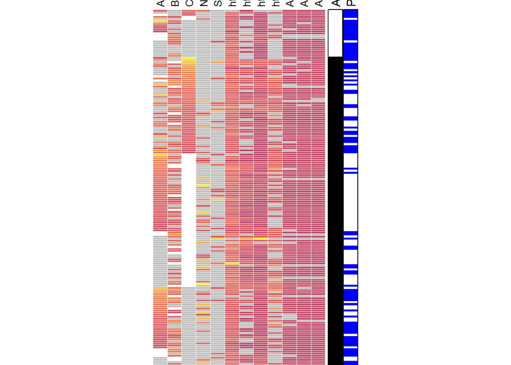

```r
# define colors for main heatmap

col_fun = colorRamp2(c(-2, 0, 2, 6), c('#F0F921FF','#E16462FF','#0D0887FF', 'gray'))
#col_fun(seq(-2, 3))

## heatmap

test_fig <- Heatmap(matrix = matrix,
                       cluster_columns = FALSE,
                       cluster_rows=FALSE,
                       name="log10-uM",
                       col=col_fun,
                       na_col='white',
                       #col= colors,
                       #col = colorRamp2(breaks = c(1, 0),
                       #                  colors = c("#2166ac", "#f7f7f7")),
                       #col = list(type=c("1" = "#2166ac","0"= "#f7f7f7")),
                       show_row_names = FALSE,
                       #row_dend_width = unit(3, "cm"),
                       column_names_max_height = unit(8, "cm"),
                       column_names_gp = gpar(fontsize = 10),
                       #clustering_method_columns = "ward.D",
                       #clustering_method_rows = "ward.D",
                    show_column_dend = FALSE,
                    show_row_dend = FALSE,
                       #clustering_distance_rows = "euclidean",
                       #clustering_distance_columns = "euclidean",
                       #show_row_dend = TRUE,
                       #show_column_dend = TRUE,
                       heatmap_legend_param = list(title = "log10-uM",
                                                   legend_direction = 'horizontal'),

                      width=unit(6,'cm'),
                       height = unit(14, 'cm'),
                       rect_gp = gpar(col = "white", lwd = 0.25),
                       column_names_side='top',
                    right_annotation = row_ha)

## final heatmap output

hm_invitro <- draw(test_fig,  heatmap_legend_side='bottom')
```

```r
## Make ComplexHeatmap zoom
mat4 <- mat2[aqc==0]
mat5 <- mat4[,lapply(.SD, function(x){ifelse(is.na(x),6,x)}), .SDcol=c(3:14)]
mat5 <- mat5 %>% mutate_all(function(x) ifelse(x==5, NA, x))
mat5 <- mat5 %>% mutate_all(function(x) ifelse(is.infinite(x), NA, x))

matrix2 <- as.matrix(mat5)
mat4[,chnm := str_trunc(chnm, 40, "right")]
rownames(matrix2) <- mat4[,chnm]
```

```r
anno_df2 <- data.frame(rownames(matrix2))

# add whether it is APCRA Pro Only and if it is in applicability domain for screening and chemical name
anno_df2$DTXSID <- mat4$dsstox_substance_id[match(anno_df2[,1],
                                                 mat4$chnm)]
anno_df2$Pro <- ad.tbl$apcra.pro.only[match(anno_df2$DTXSID,
                                            ad.tbl$DTXSID)] # 1 means APCRA pro only
anno_df2$chnm <- ad.tbl$preferred_name[match(anno_df2$DTXSID,
                                            ad.tbl$DTXSID)] # match in preferred name
anno_df2$aqc <- ad.tbl$aqc_indicator[match(anno_df2$DTXSID,
                                          ad.tbl$DTXSID)] # 1 means pass AQC

colors_ha <- list(Pro = c('0'='white','1'='blue'),
                  AQC = c('0'='white', '1'='black'))

#row_ha <- rowAnnotation(min_nam = anno_text(anno_df$min_nam,
#                                               just='left',
#                                               show_name = FALSE))


#row_ha <- rowAnnotation(Pro = anno_simple(anno_df$Pro,
#                                          col = c('0'='white','1'='black')))

row_ha <- rowAnnotation(AQC = anno_df2$aqc,
                        Pro = anno_df2$Pro,
                        col = colors_ha,
                        border=TRUE,
                        annotation_name_side = c('top','top'))
```

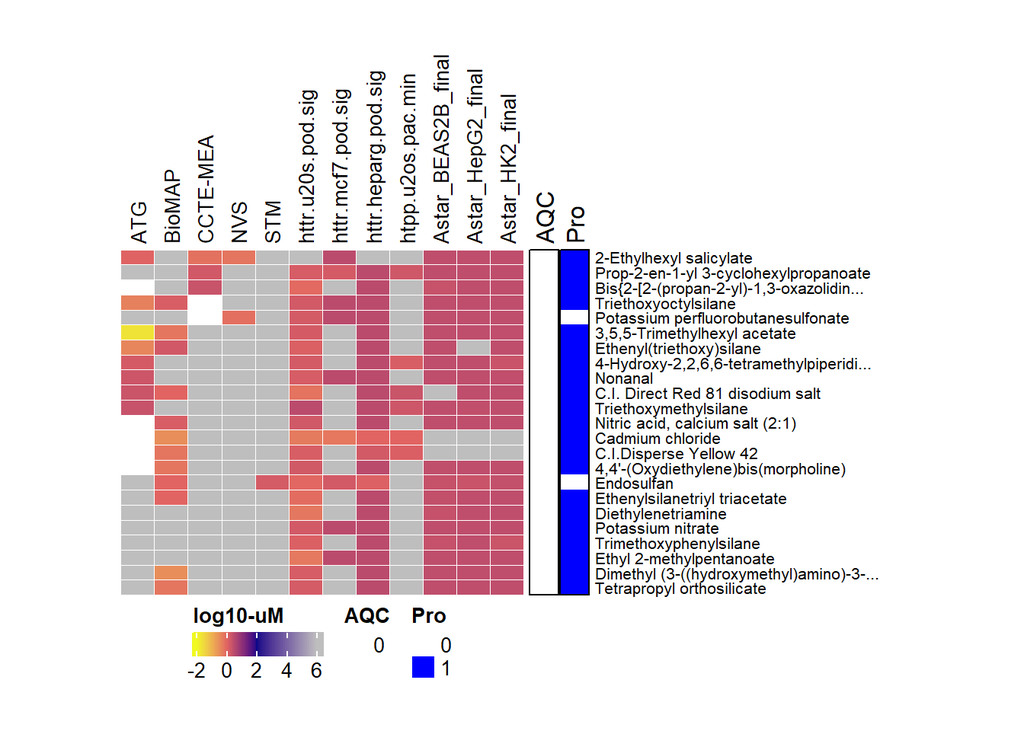

```r
# define colors for main heatmap

col_fun = colorRamp2(c(-2, 0, 2, 6), c('#F0F921FF','#E16462FF','#0D0887FF', 'gray'))
#col_fun(seq(-2, 3))

## heatmap

test_fig2 <- Heatmap(matrix = matrix2,
                       cluster_columns = FALSE,
                       cluster_rows=FALSE,
                       name="log10-uM",
                       col=col_fun,
                       na_col='white',
                       #col= colors,
                       #col = colorRamp2(breaks = c(1, 0),
                       #                  colors = c("#2166ac", "#f7f7f7")),
                       #col = list(type=c("1" = "#2166ac","0"= "#f7f7f7")),
                       show_row_names = TRUE,
                       #row_dend_width = unit(3, "cm"),
                       column_names_max_height = unit(8, "cm"),
                       column_names_gp = gpar(fontsize = 10),
                     row_names_gp=gpar(fontsize=8),
                       #clustering_method_columns = "ward.D",
                       #clustering_method_rows = "ward.D",
                    show_column_dend = FALSE,
                    show_row_dend = FALSE,
                       #clustering_distance_rows = "euclidean",
                       #clustering_distance_columns = "euclidean",
                       #show_row_dend = TRUE,
                       #show_column_dend = TRUE,
                       heatmap_legend_param = list(title = "log10-uM",
                                                   legend_direction = 'horizontal'),

                      width=unit(7,'cm'),
                       height = unit(6, 'cm'),
                       rect_gp = gpar(col = "white", lwd = 0.25),
                       column_names_side='top',
                    right_annotation = row_ha)

## final heatmap output

hm_invitro_zoom <- draw(test_fig2,  heatmap_legend_side='bottom')
```

```r
p1 = grid.grabExpr(draw(test_fig,  heatmap_legend_side='bottom'))
p2 = grid.grabExpr(draw(test_fig2,  heatmap_legend_side='bottom'))
```

```r
asnm.tier1.long <- melt.data.table(asnm.tier1,
                           id.vars = c('chnm','dsstox_substance_id'),
                           measure.vars = c('min.acc.targeted.nam','min.httr.htpp.targetnams', 'modl_acc_5p'),
                           variable.name = c('min_nam_type'),
                           value.name = c('pod_log10uM'))

d <- ggplot(data=asnm.tier1.long,
                       aes(x=pod_log10uM,
                           fill=min_nam_type))+
  geom_histogram(position='identity',binwidth = 0.33, alpha=0.5)+
  scale_x_continuous(breaks=seq(-5,10,1))+
  scale_fill_viridis(name='',
                     discrete=TRUE,
                     labels=c('min targeted',
                              'min broad',
                              '5th %-ile ToxCast'),
                     breaks=c('min.acc.targeted.nam',
                              'min.httr.htpp.targetnams',
                              'modl_acc_5p'))+
  #scale_color_viridis(discrete=TRUE)+
  theme_bw()+
  theme(axis.text = element_text(size=12),
        axis.title = element_text(size=14))+
  xlab("Min in vitro potency")+
  ylab("count")+
  theme(legend.position = 'bottom')
```

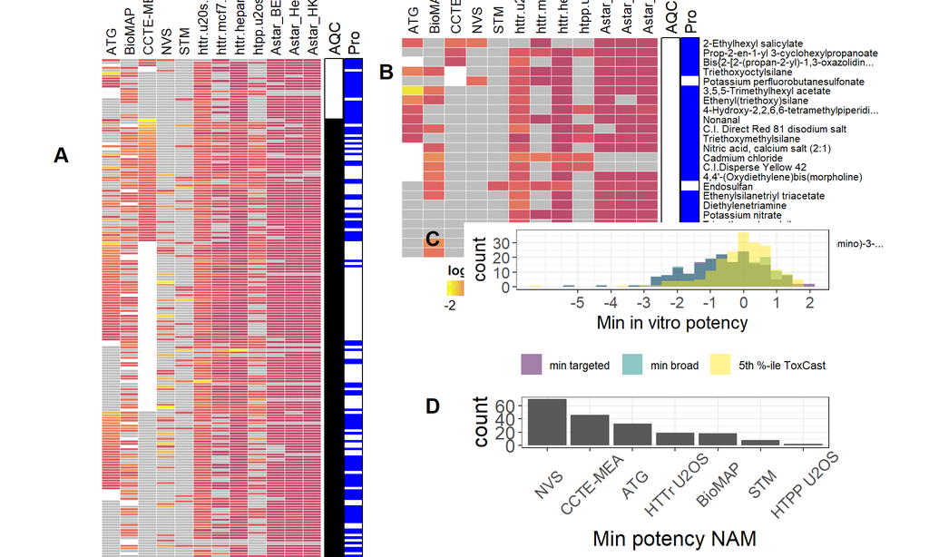

```r
fig3 <- ggdraw()+
  #draw_plot(p1,     0,  0,   0.5, 1)+
  #draw_plot(p2,    0.5, 0.3,0.4, 0.7)+
  #draw_plot(fig2b, 0.5, 0.1, 0.4, 0.3)+
  #draw_plot_label(c('A','B','C'), c(0, 0.4,0.4),
  #                c(0.8, 0.8, 0.45), size=16)
  draw_plot(p1, x=0,   y=0,  width=0.5, height=1)+
  draw_plot(p2, x=0.5, y=0.3,width=0.4, height=1)+
  draw_plot(d, x=0.5,  y=0.3,width=0.4, height=0.3)+
  draw_plot(fig2b, x=0.5, y=0, width=0.4, height=0.3)+

  draw_plot_label(c('A','B','C','D'), c(0.05, 0.4,0.45, 0.45),
                  c(0.75, 0.9, 0.6, 0.3), size=16)
fig3
```

```r
file.dir <- paste('output/', sep='')
file.name <- paste('/Fig3_in_vitro_results_', Sys.Date(), '.tiff', sep='')
file.path <- paste(file.dir, file.name, sep='')
dir.create(path=file.dir, showWarnings = FALSE, recursive = TRUE)
tiff(file.path, width=10, height=12, units='in', res=450)
fig3
dev.off()
```

```r
# add the tier 1 file to the data

save(apcra.list,
     cerapp,
     compara,
     er,
     ar,
     hth295r,
     mega.mc5,
     mega.mc5.hitc1,
     sc2.stm,
     httr.pod,
     PACList.apcra,
     asnm.tier1,
     file='./source/in_vitro/tier1_NAMs_apcra_pro_02262024.RData')
```